# Phys474_S23_Hwk6

Physics 474 - Spring 2023

Homework 6 - Practice with random numbers and monte carlo techniques

generating and comparing "fake" data to theory used to generate it, and checking the $\chi^2$ distribution.

Author: Gordon Moss

Problem 1 Background:

We will generate data with random errors from a given theoretical function and then calculate the $\chi^2$ between the theory function and the generated data with random erros

In part a: you will do this once at a time and plot the theory with the monte carlo generated data

In part b: you will

- do this many, many times $N_{trial} = 100,000$
- get the $\chi^2$ for each trial
- plot the distribution of the $\chi^2$'s you get
- compare it to the true $\chi^2$ distribution

Problem 1:

For this problem we will use the theory function for the period of a pendulum

$ T = \sqrt{\frac{L}{g}}$

use

- $L$ = .1, .25, .5, .75, 1.0, 1.25, 1.5 $m$
- $g$ = 9.8 $m/s^2$
- $\sigma_{T}$ = .01 $s$
- $\sigma_{L}$ = 0 $m$, that is ignore errors on the "measured" $L$

part a: (5 pts)

- generate experimental data for the period $T$
- plot the data with errorbars and the perfect theory used to generate it
- calculate and display on graph the $\chi^2$ and Prob bewteen the two

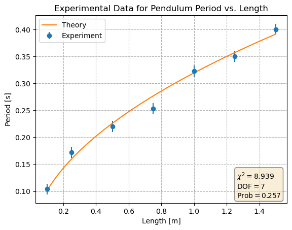

```python
import numpy as np
import matplotlib.pyplot as plt
import scipy.stats as st


def gen_experiment(L):
    T = np.sqrt(L / g)
    return np.random.normal(T, sig_T)

def get_chi2(thry, data):
    return np.sum(((data - thry) / sig_T) ** 2)


lengths = [.1, .25, .5, .75, 1.0, 1.25, 1.5]      # [m]
g = 9.8                                           # [m/s^2]
sig_T = 0.01                                      # [s]

Ls = np.array(lengths)
Ts = gen_experiment(Ls)
T_thry = np.sqrt(Ls / g)

L_thry_plot = np.linspace(Ls.min(), Ls.max(), 100)
T_thry_plot = np.sqrt(L_thry_plot / g)

dof = len(Ls)
chi2 = get_chi2(T_thry, Ts)
prob = st.chi2.sf(chi2, dof)

plt.errorbar(Ls, Ts, yerr=sig_T, fmt='o', label='Experiment')
plt.plot(L_thry_plot, T_thry_plot, label='Theory')
text = r"""$\chi^2={:.3f}$
DOF$={}$
Prob$={:.3f}$""".format(chi2, dof, prob)
plt.text(.8, .02, text, ha='left', va='bottom', transform=plt.gca().transAxes,
         bbox=dict(boxstyle='round', facecolor='wheat', alpha=0.5))

plt.title('Experimental Data for Pendulum Period vs. Length')
plt.xlabel('Length [m]')
plt.ylabel('Period [s]')

plt.grid(linestyle='--')
plt.legend(loc='upper left')
plt.show()
```

Observations:

- Run the cell above several times

Summarize what you get

part b: (10 pts)

Now do the same thing you did once above but 100,000 times.

- Plot the histogram of $\chi^2$ distribution from the 100,000 trials in 40 bins
- overlay a plot of the actual expected $\chi^2$ probability distribution function from scipy.stats.chi2.pdf(values,dof). Don't forge to normalize the probability distribution function to the number of trials, and use the correct degrees of freedom (i.e. dof = number of data points in the T vs L data)

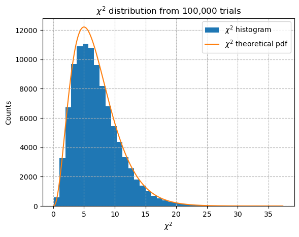

```python
Ls = np.vstack([lengths] * 100000)
Ts = gen_experiment(Ls)
T_thry = np.sqrt(Ls / g)

chi2 = np.sum(((Ts - T_thry) / sig_T) ** 2, axis=1)
chi2.sort()
prob = st.chi2.sf(chi2, dof)
pdf = st.chi2.pdf(chi2, dof)

plt.hist(chi2, bins=40, label=r'$\chi^2$ histogram')
plt.plot(chi2, pdf * 100000, label=r'$\chi^2$ theoretical pdf')

plt.title('$\chi^2$ distribution from 100,000 trials')
plt.xlabel('$\chi^2$')
plt.ylabel('Counts')

plt.legend()
plt.grid(linestyle='--')
plt.show()
```

Observations:

- In particular, how does the $\chi^2$ distribution between MC data (with random error) and Theory compare to the expected $\chi^2$ probability distribution function predicted by assumeing random guassian errors for each degree of freedom?

The $\chi^2$ distribution for the MC data very closely follows the expected probability density function, with minor deviations which vary from run to run.

Problem 2: (5 pts)

You are designing an experiment that will measure the characteristic lifetime of a state (e.g. an excited atomic state emitting photons, or nuclear decay emitting charged particle). The number of decays you expect versus time is given by the simple exponential decay function

$N(t) = \frac{N_0}{\tau}e^{-t/\tau}$

where $\tau$ is the characteristic lifetime you would be trying to measure and $N_0$ is the number of initial exctited states. Note that integral of $\int_0^\infty N(t) \, dt = N_0$

To test the sensitivity of your possible measurement of the lifetime $\tau$ to the expected MEAN number of excited states $<N_0>$ you would write a monte carlo simulating $N(t)$ for various actual $N_0$, after Poisson fluctuations. Then you could fit that simulated $N(t)$ for the lifetime $\tau$ over many simulated datasets to estimate your sensitivity for $\tau$ versus $<N_0>$. This would tell you what $<N_0>$ you would need to have in this hypothetical experiment you will design.

We won't go through this entire process. I am asking for just the first step

- generate simulated dataset of decays given mean expected number $N_0$ and a lifetime $\tau$

For this problem assume:

- $<N_0>=4000$
- $\tau = 1s$

you need to:

- pick a random $N_0$ using $<N_0>$ from a poisson probability distribution with $\mu=<N_0>$
- for that random $N_0$ generate the time of the decays randomly according to the exponential decay probaility distribution.
- Plot a histogram with errorbars $\sigma_{bin}=\sqrt{n_{bin}}$ of the frequency of events versus time for $40$ bins from

$\,\,\,\,\,\, 0 \le t \le 4\tau$

- overlay a plot of the theory expected $N(t)$

$\,\,\,\,\,\, N(t) = \frac{<N_0>}{\tau}e^{-t/\tau}$

- Show $<N_0>$ and $N_0$ in legend
- compare the binned mc data to the theory and put $\chi^2$, dof, $\chi^2$-probability on plot

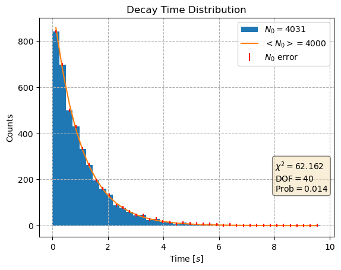

```python
N0_mean = 4000
tau = 1           #  [s]
n_bins = 40
trials = 100000

N0 = np.random.poisson(N0_mean)
ts = np.random.exponential(tau, size=N0)
err = np.sqrt(n_bins)

hist, bins, _ = plt.hist(ts, bins=n_bins, label='$N_0={}$'.format(N0))
bins = bins[:-1] + (bins[1] - bins[0]) / 2  # centering bins

N_thry = 1 / tau * np.exp(-bins / tau)
N_thry *= N0_mean / np.sum(N_thry)        # normalizing

chi2 = np.sum(((hist - N_thry) / err) ** 2)
dof = len(hist)
prob = st.chi2.sf(chi2, dof)

plt.plot(bins, N_thry, label='$<N_0>={}$'.format(N0_mean))
plt.errorbar(bins, hist, yerr=err, linestyle='none', color='red', label=r'$N_0$ error')
text = r"""$\chi^2={:.3f}$
DOF$={}$
Prob$={:.3f}$""".format(chi2, dof, prob)
plt.text(.8, .2, text, ha='left', va='bottom', transform=plt.gca().transAxes,
         bbox=dict(boxstyle='round', facecolor='wheat', alpha=0.5))

plt.title('Decay Time Distribution')
plt.xlabel(r'Time $[s]$')
plt.ylabel('Counts')

plt.legend()
plt.grid(linestyle='--')
plt.show()
```

Observations:

The theoretical distribution visually appears to fit the data, but the $\chi^2$ probability is low.